# MEGENA example pipeline

Minghui Wang

Oct 22, 2023

This pipeline is based on MEGENA v1.3.7 https://CRAN.R-project.org/package=MEGENA, adapted from Won-Min Song’s 02/20/2020 vignette for MEGENA v1.3.6.

# Load library and set up parameters

```r
if(! require('MEGENA')) install.packages('MEGENA')
library('MEGENA')
n.cores = 2; # number of cores/threads to call for PCP
doPar = TRUE; # do we want to parallelize?
method = "pearson" # method for correlation. either pearson or spearman.
FDR.cutoff = 0.05 # FDR threshold to define significant correlations upon shuffling samples.
module.pval = 0.05 # module significance p-value. Recommended is 0.05.
hub.pval = 0.05 # connectivity significance p-value based random tetrahedral networks
cor.perm = 10; # number of permutations for calculating FDRs for all correlation pairs.
hub.perm = 100; # number of permutations for calculating connectivity significance p-value.
```

# Calculate pairwise correlations

```r
data(Sample_Expression) # load toy example data
print(dim(datExpr))
```

```
## [1] 300 844
```

```r
datExpr[1:5, 1:10] #check the first few rows and columns.
```

```
##          TCGA-E9-A1RC-01A-11R-A157-07 TCGA-BH-A0B1-01A-12R-A056-07
## C1QB                         7.799198                     9.491122
## CD3E                         2.703622                     6.570632
## CD3D                         1.121214                     4.802647
## TMEM176A                     6.608023                     8.948846
## C1QA                         7.644438                     9.371917
##          TCGA-B6-A0RG-01A-11R-A056-07 TCGA-D8-A1JH-01A-11R-A13Q-07
## C1QB                         9.959445                    10.648426
## CD3E                         5.812081                     8.074163
## CD3D                         4.104806                     6.152895
## TMEM176A                    10.054326                     8.760917
## C1QA                         9.645062                    10.757832
##          TCGA-BH-A0DS-01A-11R-A056-07 TCGA-A2-A0D1-01A-11R-A034-07
## C1QB                        10.950035                     8.871837
## CD3E                         7.853811                     6.475819
## CD3D                         6.448691                     5.098223
## TMEM176A                     9.705381                     8.099016
## C1QA                        11.029782                     8.917343
##          TCGA-BH-A0HW-01A-11R-A034-07 TCGA-A8-A08B-01A-11R-A00Z-07
## C1QB                         8.289862                    10.158735
## CD3E                         2.326334                     8.201973
## CD3D                         1.038819                     5.995388
## TMEM176A                     5.842051                     8.097762
## C1QA                         8.375034                    10.336271
##          TCGA-A8-A07W-01A-11R-A00Z-07 TCGA-AR-A2LK-01A-11R-A180-07
## C1QB                        11.407055                     9.856734
## CD3E                         7.375115                     6.636695
## CD3D                         5.687467                     5.183467
## TMEM176A                     8.364050                    10.207439
## C1QA                        11.159033                     9.642598
```

```r
# Optional gene annotation to be done on the downstream.
annot.table = NULL #Should be a data.frame with at least two columns to map Ensembl gene ids to symbols. Will skip this step when NULL.
id.col = 1
symbol.col = 2
###########

rho.out = calculate.correlation(datExpr, doPerm = 10, FDR.cutoff = FDR.cutoff, method = method)
```

```
## i = 1
## i = 2
## i = 3
## i = 4
## i = 5
## i = 6
## i = 7
## i = 8
## i = 9
## i = 10
## - outputting correlation results...
```

# Planar Filtered Network (PFN)

In this step, Planar Filtered Network (PFN) is calculated by taking significant correlation pairs, ijw. In the case of utilizing a different similarity measure, one can independently format the results into 3-column data frame with column names c(“row”,“col”,“weight”), and make sure the weight column ranges within 0 to 1. Using this as an input to calculate.PFN() will work just as fine.

```r
#### register multiple cores if needed: note that set.parallel.backend() is deprecated.
run.par = doPar & (getDoParWorkers() == 1)
if (run.par)
{
  cl <- parallel::makeCluster(n.cores)
  registerDoParallel(cl)
  # check how many workers are there
  cat(paste("number of cores to use:",getDoParWorkers(),"\n",sep = ""))
}
```

```
## number of cores to use:2
```

```r
##### Calculate PFN
el <- calculate.PFN(rho.out, doPar = doPar, num.cores = n.cores, keep.track = FALSE)
```

```
## ####### PFN Calculation commences ########
## [1] "343 out of 894 has been included."
## [1] "471 out of 894 has been included."
## [1] "556 out of 894 has been included."
## [1] "Performing parallel quality checks on 2000"
## [1] "Qualified edges: 249"
## [1] "663 out of 894 has been included."
## [1] "710 out of 894 has been included."
## [1] "Performing parallel quality checks on 2000"
## [1] "Qualified edges: 78"
## [1] "759 out of 894 has been included."
## [1] "Performing parallel quality checks on 2000"
## [1] "Qualified edges: 60"
## [1] "802 out of 894 has been included."
## [1] "Performing parallel quality checks on 2000"
```

[output cut: 51 more lines]

```r
g <- graph.data.frame(el,directed = FALSE)
```

# Multi-scale clustering

MCA clustering is performed to identify multiscale clustering analysis. “MEGENA.output”” is the core output to be used in the down-stream analyses for summarization and plotting.

```r
##### Perform MCA clustering.
MEGENA.output <- do.MEGENA(g,
 mod.pval = module.pval,hub.pval = hub.pval,remove.unsig = TRUE,
 min.size = 10,max.size = vcount(g)/2,
 doPar = doPar,num.cores = n.cores,n.perm = hub.perm,
 save.output = FALSE)

###### unregister cores as these are not needed anymore.
if (getDoParWorkers() > 1)
{
  env <- foreach:::.foreachGlobals
  rm(list=ls(name=env), pos=env)
}
```

# Summarize results

```r
summary.output <- MEGENA.ModuleSummary(MEGENA.output,
    mod.pvalue = module.pval,hub.pvalue = hub.pval,
    min.size = 10,max.size = vcount(g)/2,
    annot.table = annot.table,id.col = id.col,symbol.col = symbol.col,
    output.sig = TRUE)

if (!is.null(annot.table))
{
  # update annotation to map to gene symbols
  V(g)$name <- paste(annot.table[[symbol.col]][match(V(g)$name,annot.table[[id.col]])],V(g)$name,sep = "|")
  summary.output <- output[c("mapped.modules","module.table")]
  names(summary.output)[1] <- "modules"
}

print(head(summary.output$modules,2))
```

```
## $c1_2
##   [1] "C1QB"         "C1QA"         "SASH3"        "HLA-DPA1"     "PLEK"
##   [6] "NCKAP1L"      "EVI2B"        "HLA-DRA"      "FCGR1A"       "CD53"
##  [11] "PTPRC"        "DOCK2"        "ITGB2"        "FCGR1C"       "ARHGAP9"
##  [16] "CD37"         "CD4"          "PTPN7"        "HLA-DMB"      "CD48"
##  [21] "FYB"          "CYBB"         "IKZF1"        "LILRB2"       "HLA-DQA1"
##  [26] "LILRB4"       "IL10RA"       "CCR5"         "HLA-DPB1"     "LILRB1"
##  [31] "CORO1A"       "SPN"          "PSTPIP1"      "SNX20"        "MNDA"
##  [36] "TFEC"         "FGL2"         "CD74"         "C1QC"         "ITGAX"
##  [41] "FERMT3"       "CCR1"         "PRKCB"        "CD1E"         "HLA-DQB1"
##  [46] "IL12RB1"      "NCF1C"        "CLEC10A"      "FPR3"         "WDFY4"
##  [51] "SP140"        "FCGR3A"       "CTSS"         "BIN2"         "SIGLEC7"
##  [56] "TLR8"         "HLA-DRB1"     "IFI30"        "GPR183"       "NCF2"
##  [61] "TMC8"         "MRC1"         "GIMAP5"       "CLEC17A"      "CD86"
##  [66] "PIK3AP1"      "CSF1R"        "CD163"        "P2RY13"       "DOK2"
```

[output cut: 36 more lines]

```r
print(summary.output$module.table)
```

```
##       module.id module.size module.parent
## c1_2       c1_2         133          c1_1
## c1_3       c1_3         121          c1_1
## c1_4       c1_4          22          c1_1
## c1_5       c1_5          24          c1_1
## c1_6       c1_6          26          c1_2
## c1_7       c1_7          68          c1_2
## c1_10     c1_10          65          c1_3
## c1_12     c1_12          25          c1_3
## c1_13     c1_13          11          c1_3
## c1_19     c1_19          22          c1_7
## c1_21     c1_21          56         c1_10
## c1_23     c1_23          11         c1_12
##                                                                  module.hub
## c1_2  SASH3(34),CD53(33),PTPRC(26),CD86(20),NCKAP1L(19),FERMT3(19),PLEK(18)
## c1_3                           CD2(33),CD3E(32),GBP5(20),ITK(19),SLAMF6(18)
## c1_4                                                              MS4A1(12)
## c1_5                                                    IFIT3(19),IFIT1(12)
## c1_6                                                               CD86(14)
## c1_7                        CD53(32),SASH3(27),PLEK(17),NCKAP1L(17),CD4(16)
## c1_10                                                      CD2(32),CD3E(29)
## c1_12                                                            SLAMF6(14)
## c1_13                                                              PSMB9(9)
## c1_19                                                   SASH3(19),PTPN7(12)
## c1_21                                                      CD2(32),CD3E(29)
## c1_23                                                            SLAMF6(10)
##       module.scale module.pvalue
## c1_2            S4          0.00
## c1_3          <NA>          0.00
## c1_4            S4          0.00
## c1_5            S4          0.00
## c1_6            S3          0.03
## c1_7          <NA>          0.00
## c1_10         <NA>          0.00
## c1_12           S4          0.00
## c1_13           S4          0.00
## c1_19           S3          0.00
## c1_21           S4          0.00
## c1_23           S3          0.00
```

Write the module results into files.

```
saveRDS(summary.output, file = 'summary.output.RDS')
modules <- do.call(rbind, lapply(names(summary.output$modules), function(x) data.frame(Gene = summary.output$modules[[x]], Module = x, stringsAsFactors = FALSE)))
write.table(modules, file = "module.dataframe.tsv", sep = "\t", quote = FALSE, row.names = FALSE)
write.table(summary.output$module.table, file = "module.summary.tsv", sep = "\t", quote = FALSE, row.names = FALSE)
```

# Plot some modules

You can generate refined module network plots:

```r
library(ggplot2)
library(ggraph)

pnet.obj <- plot_module(output.summary = summary.output, PFN = g,subset.module = "c1_3",
    layout = "kamada.kawai",label.hubs.only = TRUE,
    gene.set = NULL,color.code =  "grey",
    output.plot = FALSE,out.dir = "modulePlot",col.names = c("magenta","green","cyan"),label.scaleFactor = 20,
    hubLabel.col = "black",hubLabel.sizeProp = 1,show.topn.hubs = Inf,show.legend = TRUE)
```

```
## Processing module:c1_3
##  - # of genes: 121
##  - # of hubs: 5
## - generating module subnetwork figure...
```

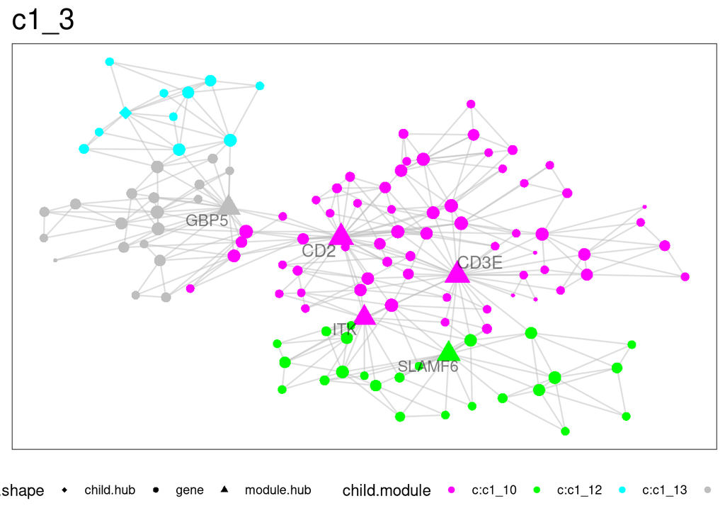

```r
print(pnet.obj[[1]])
```

# Test gene ontology (GO)/pathway enrichment in modules

There are quite a number of R packages available for performing GO/pathway enrichment analysis. For this tutorial, we will use my R package GOtest.

First, install GOtest and its dependency msigdbi.

```r
devtools::install_github("mw201608/msigdb")
devtools::install_github("mw201608/GOtest")
```

Then, we run the enrichment analysis with the hypergeometric test (equivalent to Fisher’s exact test) by calling the msigdb.gsea function.

```r
enr_table = GOtest:::msigdb.gsea(x = modules[, c('Gene', 'Module')], background = 'annotation', genesets = c('c2.cp', 'c5.go.bp', 'c5.go.cc', 'c5.go.mf'), name.x = 'Module', method = 'hypergeometric')
head(enr_table, 5)
```

```
##         System                                            MSigDB Module
## 3898  c5.go.bp                             GOBP_DEFENSE_RESPONSE   c1_2
## 3329  c5.go.bp          GOBP_REGULATION_OF_IMMUNE_SYSTEM_PROCESS   c1_2
## 3331  c5.go.bp GOBP_POSITIVE_REGULATION_OF_IMMUNE_SYSTEM_PROCESS   c1_2
## 16436 c5.go.bp          GOBP_REGULATION_OF_IMMUNE_SYSTEM_PROCESS   c1_3
## 7415  c5.go.bp                GOBP_REGULATION_OF_IMMUNE_RESPONSE   c1_2
##       Overlap.Size Module.Size MSigDB.Size Background.Size       FE
## 3898            75         129        1790           19590 6.362869
## 3329            68         129        1593           19590 6.482430
## 3331            58         129        1050           19590 8.388483
## 16436           62         109        1593           19590 6.994938
## 7415            56         129         993           19590 8.564135
##             Pvalue        P.adj
## 3898  1.776301e-44 2.793838e-39
## 3329  6.099364e-40 4.796662e-35
## 3331  2.791285e-39 1.426957e-34
## 16436 3.628995e-39 1.426957e-34
## 7415  3.056106e-38 9.613533e-34
##                                                                                                                                                                                                                                                                                                          …
## 3898  AOAH;C1QA;C1QB;C1QC;CARD11;CCR1;CCR4;CCR5;CD163;CD180;CD200R1;CD209;CD226;CD28;CD4;CD48;CD74;CD84;CIITA;CLEC10A;CORO1A;CRTAM;CSF1;CSF1R;CYBB;FCGR1A;FCGR1B;FCGR2B;FCN1;FGL2;FPR3;HCK;HLA-DPA1;HLA-DPB1;HLA-DQA1;HLA-DQB1;HLA-DRA;HLA-DRB1;HLA-DRB5;IFI30;IL12RB1;IL16;IRF8;ITGAL;ITGB2;LILRA5;LILRB…
## 3329                               C1QA;C1QB;C1QC;CARD11;CCR1;CD1A;CD1C;CD1E;CD200R1;CD209;CD226;CD28;CD4;CD48;CD74;CD84;CD86;CLEC10A;CORO1A;CRTAM;CSF1;CSF1R;EBI3;EVI2B;FCGR1A;FCGR1B;FCGR2B;FCGR3A;FCN1;FGL2;FPR3;GPR183;HCK;HCLS1;HLA-DMB;HLA-DOA;HLA-DPA1;HLA-DPB1;HLA-DQA1;HLA-DQB1;HLA-DRA;HLA-DRB1…
## 3331                                                                                                    C1QA;C1QB;C1QC;CARD11;CCR1;CD1A;CD1C;CD1E;CD209;CD226;CD28;CD4;CD74;CD84;CD86;CLEC10A;CORO1A;CRTAM;CSF1;CSF1R;EBI3;EVI2B;FCGR1A;FCGR2B;FCGR3A;FCN1;FPR3;GPR183;HCK;HCLS1;HLA-DMB;HLA-DPA1;HLA-DPB…
## 16436                                                                                                              AIM2;BTLA;CCL4;CCL5;CD2;CD247;CD27;CD38;CD3D;CD3E;CD3G;CD40LG;CD5;CD6;CD80;CD8A;CD8B;CD96;CLEC4D;CLEC4E;CST7;CTLA4;CXCL10;CXCR3;FCRL3;GBP1;GBP5;GPR171;HLA-B;HLA-F;HLA-H;ICOS;IDO1;IFN…
## 7415                                                                                                             C1QA;C1QB;C1QC;CARD11;CD1A;CD1C;CD1E;CD200R1;CD209;CD226;CD28;CD4;CD48;CD74;CD84;CD86;CLEC10A;CRTAM;FCGR1A;FCGR1B;FCGR2B;FCGR3A;FCN1;FGL2;FPR3;HCK;HLA-DMB;HLA-DPA1;HLA-DPB1;HLA-DQA1;HL…
```

```r
enr_table <- enr_table[enr_table$P.adj <= 0.05, ]
write.table(enr_table, file = "module.msgidb.tsv", sep = "\t", quote = FALSE, row.names = FALSE)
```

# Plot module hierarchy

We can visualize the module hierarchy as well as some optional module annotations by using a sunburst plot.

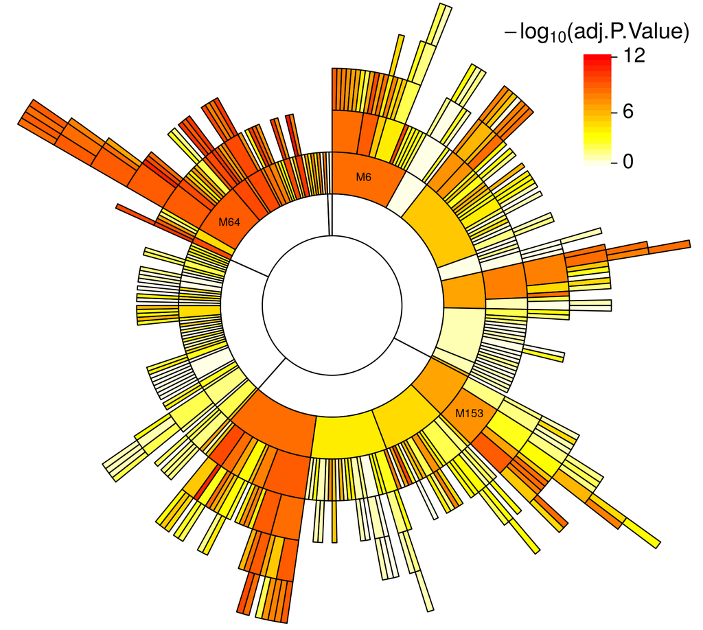

Example sunburst plot.

To create a sunburst plot, you can check my Shiny app https://github.com/mw201608/sunburst.shiny.